# Презентации и данные

**Внимание!** Распределение тем по датам занятий очень условное. Возможно, что все переиграется по мере развития событий.

## 1. Знакомство с R (11 марта 13:00-14:30)

- Презентация: 01_intro_to_r.html
- Код для работы на лекции: 01_intro to R_student_script.R
- Данные для работы на лекции: hydrology_2022.xls

### Домашнее задание

- Домашнее задание:Вариант 1
- Домашнее задание:Вариант 2
- Данные для выполнения домашнего задания: catsM.xls

## 2. Данные и их визуализация с использованием пакета `ggplot2`

### Домашнее задание

#### Первая часть ДЗ

**Ваша миссия:** Скачайте данные по водному тесту за 2022 или 2023 гг. В этом файле найдите лист “Север”. Переделайте данные этого листа так, чтобы из него получилось два датасета: один по описанию параметров гнезд (ID гнезда, Дата, Место, Число яиц, Срок насиживания, Начало насиживания, Вылупление), второй по водному тесту (ID гнезда, У1, У2, У3, Д1, Д2, Д3). Но! оба датасета необходимо представить в **длинном** формате с соблюдением правил **tidy data**.

Внимание! Второй датсет совсем не прост, подумайте какие перменные там должны быть.

Оба датасета необходимо сохранить в формате csv.

Результаты (два csv файла) необходимо выслать до 23:59 четверга 21 марта.

#### Вторая часть ДЗ

**Ваша миссия:** Используйте переведенные в длинный формат данные по водному тесту, полученные на предыдущем шаге ДЗ. У вас должно быть два файла: nest.csv и eggs.csv.

**Важно!** Электронные таблицы (с российскими настройками) в файлах csv в качестве разделителя обычно используют не запятую, а точку с запятой. Посмотрите на свои csv файлы через блокнот и выясните, какой разделител у вас.

Скопируйте к себе в RStudio код приведенный ниже. Пройдите его, подумайте, что осуществляется в этом коде.

```r
library(dplyr)

nest <- read.table("data/nest.csv", sep = ";", header = TRUE, encoding = "utf8")

eggs <- read.table("data/eggs.csv", sep = ";", header = TRUE, encoding = "utf8")

eggs_angle <-
  eggs %>%
  filter(Parameter_Type == "Angle") %>%
  filter(Value != "взв")

eggs_angle$Value <- as.numeric(eggs_angle$Value)

eggs_angle_mean <-
  eggs_angle %>%
  group_by(ID) %>%
  summarise(Mean_Angle = mean(Value))

eggs_angle_mean_nest <- merge(eggs_angle_mean, by = "ID", nest) # Функция merge(), позволяет
# объединить два датасета, у которых есть общая переменная
```

Далее, используя датасет `eggs_angle_mean_nest` постройте вот такой график

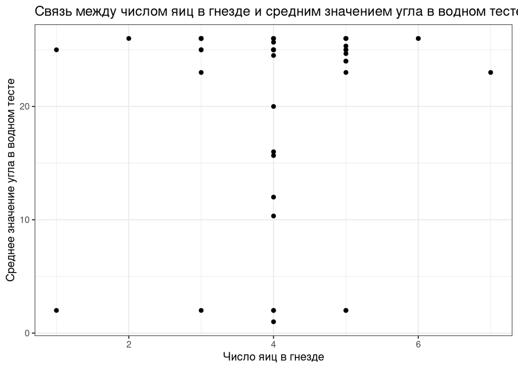

В качестве ответа необходимо прислать код, который будет включать все этапы построения графика (включая подготовку данных)

## 3. Описание данных с помощью статистических показателей. Оценка параметров распределения

## 4. Тестирование статистических гипотез

**Дальнейшие планы корректируются…**

# Оценки за домашние работы

| Name | HW1 | HW2 |
| --- | --- | --- |
| Феликс | 150 | 0 |
| Вероника | 150 | 0 |
| Мария | 150 | 50 |